# Project3_Term_Deposit_Sale_Hakeem_Ogunleye-Final

#### Apply Bagging Classifier Algorithm and print the accuracy

```python
from sklearn.ensemble import BaggingClassifier

bgcl = BaggingClassifier(n_estimators=50, max_samples= .7, bootstrap=True, oob_score=True, random_state=r_seed)
bgcl = bgcl.fit(X_train, y_train)
```

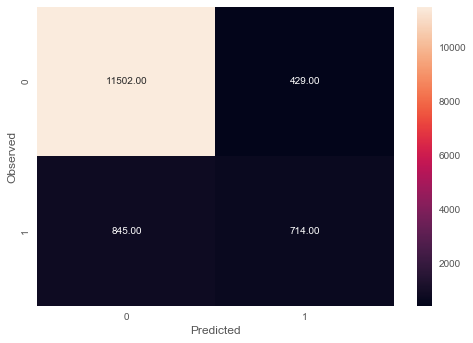

```python
pred_BG = bgcl.predict(X_test)
acc_BG = accuracy_score(y_test, pred_BG)

bg_recall = recall_score(y_test,pred_BG)
bg_precision = precision_score(y_test,pred_BG)
bg_f1_score = f1_score(y_test,pred_BG)
bg_roc = roc_auc_score(y_test,pred_BG)

draw_cm(y_test,pred_BG)
```

```python
tempResultsDf = pd.DataFrame({'Method':['Bagging'], 'accuracy': [acc_BG],'recall': [bg_recall], 'precision': [bg_precision], 'f1 score': [bg_f1_score], 'ROC AUC': [bg_roc]})
resultsDf = pd.concat([resultsDf, tempResultsDf])
resultsDf = resultsDf[['Method', 'accuracy', 'recall', 'precision', 'f1 score', 'ROC AUC']]
resultsDf
```

|  | Method | accuracy | recall | precision | f1 score | ROC AUC |
| --- | --- | --- | --- | --- | --- | --- |
| 0 | Logistic Regression | 0.8995 | 0.3258 | 0.6248 | 0.4283 | 0.6501 |
| 0 | Decision Tree | 0.8987 | 0.4586 | 0.5780 | 0.5114 | 0.7074 |
| 0 | Random Forest | 0.9035 | 0.3964 | 0.6313 | 0.4870 | 0.6831 |
| 0 | Adaboost | 0.8973 | 0.2219 | 0.6680 | 0.3332 | 0.6038 |
| 0 | Bagging | 0.9056 | 0.4580 | 0.6247 | 0.5285 | 0.7110 |

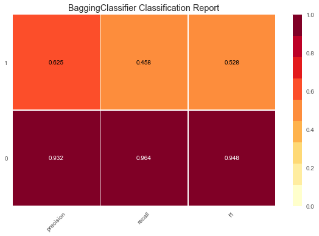

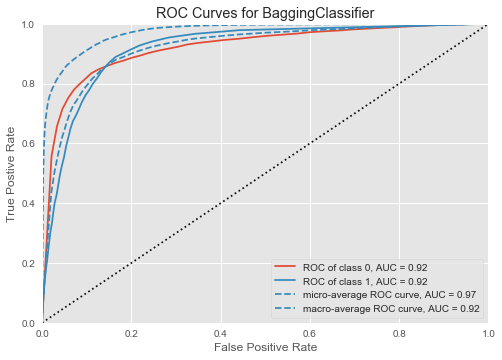

```python
# Visualize model performance with yellowbrick library
viz = ClassificationReport(bgcl)
viz.fit(X_train, y_train)
viz.score(X_test, y_test)
viz.show()

roc = ROCAUC(bgcl)
roc.fit(X_train, y_train)
roc.score(X_test, y_test)
roc.show()
```

#### Apply GradientBoost Classifier Algorithm for the same data and print the accuracy

```python
from sklearn.ensemble import GradientBoostingClassifier
gbcl = GradientBoostingClassifier(n_estimators = 50, learning_rate = 0.1, random_state=r_seed)
gbcl = gbcl.fit(X_train, y_train)
```

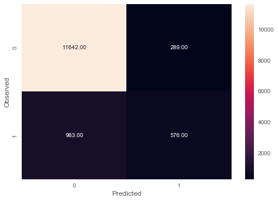

```python
pred_GB = gbcl.predict(X_test)
acc_GB = accuracy_score(y_test, pred_GB)

gb_recall = recall_score(y_test,pred_GB)
gb_precision = precision_score(y_test,pred_GB)
gb_f1_score = f1_score(y_test,pred_GB)
gb_roc = roc_auc_score(y_test,pred_GB)

draw_cm(y_test,pred_GB)
```

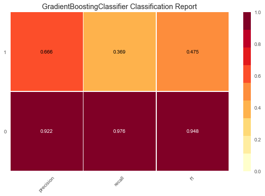

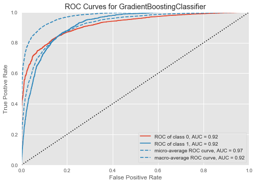

```python
# Visualize model performance with yellowbrick library
viz = ClassificationReport(gbcl)
viz.fit(X_train, y_train)
viz.score(X_test, y_test)
viz.show()

roc = ROCAUC(gbcl)
roc.fit(X_train, y_train)
roc.score(X_test, y_test)
roc.show()
```

```python
tempResultsDf = pd.DataFrame({'Method':['Gradient Boost'], 'accuracy': [acc_GB],'recall': [gb_recall], 'precision': [gb_precision], 'f1 score': [gb_f1_score], 'ROC AUC': [gb_roc]})
resultsDf = pd.concat([resultsDf, tempResultsDf])
resultsDf = resultsDf[['Method', 'accuracy', 'recall', 'precision', 'f1 score', 'ROC AUC']]
resultsDf
```

|  | Method | accuracy | recall | precision | f1 score | ROC AUC |
| --- | --- | --- | --- | --- | --- | --- |
| 0 | Logistic Regression | 0.8995 | 0.3258 | 0.6248 | 0.4283 | 0.6501 |
| 0 | Decision Tree | 0.8987 | 0.4586 | 0.5780 | 0.5114 | 0.7074 |
| 0 | Random Forest | 0.9035 | 0.3964 | 0.6313 | 0.4870 | 0.6831 |
| 0 | Adaboost | 0.8973 | 0.2219 | 0.6680 | 0.3332 | 0.6038 |
| 0 | Bagging | 0.9056 | 0.4580 | 0.6247 | 0.5285 | 0.7110 |
| 0 | Gradient Boost | 0.9057 | 0.3695 | 0.6659 | 0.4752 | 0.6726 |

### 3.3 Model Comparison and Conclusion

**Confusion matrix meaning**

*True Positive (observed=1,predicted=1):*

Predicted that term deposit should be offered and the customer will subscribe to term deposit.

*False Positive (observed=0,predicted=1):*

Predicted that term deposit should be offered to customer but unfortunately the customer will not subscribe to term deposit.

*True Negative (observed=0,predicted=0):*

Predicted that term deposit should not be offered and the customer will not subscribe to term deposit.

*False Negative (observed=1,predicted=0):*

Predicted that term deposit should not be offered but the customer would have subscribed to the term deposit

Since the bank wants to improve/increase the number of customers who will subscribe to term deposit offer, we want to reduce False Negatives (FN). If FN is high, then it means the bank would not make as much money from the investments derived from the term depoists as we are predicting that customers who would have subscibedto the term deposit wouldn't subscribe to it. **Recall** is therefore an important metric that we want to optimize (i.e. get as much true positives as possible correctly and reduce FN as much as posible).

Using the table above showing comparison of six techniques. **"Decision Tree" (45.86%)** and **"Bagging" (45.8%)** have the highest Recall percentage (with Decison tree being just slightly better) so either could be selected.  
**However, i would select Bagging because it has a slightly higher F-score, accuracy and precision as compared to Decision Tree.**